# hw 4

## 1. Bike Renting program

[figure not shown]

In this miniproject you’ll examine some factors that may influence the use of bicycles in a bike-renting program. The data come from Washington.

Two data tables are available:

- `Stations` gives the locations of the bike rental stations.
- `Trips` contains records of individual rentals.

You can access the data like this.

```r
Stations <- mosaic::read.file("http://tiny.cc/dcf/DC-Stations.csv")
data_site <- "http://tiny.cc/dcf/2014-Q4-Trips-History-Data-Small.rds"
Trips <- readRDS(gzcon(url(data_site)))
```

The `Trips` data table is a random subset of 10,000 trips from the full quarterly data.

### Time of day

It’s natural to expect that bikes are rented more at some times of day than others. The variable `sdate` gives the time (including the date) that the rental started.

|  | duration | sdate | sstation | edate | estation | bikeno | client |
| --- | --- | --- | --- | --- | --- | --- | --- |
| 344758 | 0h 9m 15s | 2014-11-06 16:26:00 | 15th & L St NW | 2014-11-06 16:35:00 | 15th & L St NW | W00169 | Registered |
| 113251 | 0h 47m 21s | 2014-10-12 11:30:00 | 3rd & D St SE | 2014-10-12 12:17:00 | Jefferson Dr & 14th St SW | W01482 | Registered |
| 633756 | 2h 46m 22s | 2014-12-27 14:24:00 | 10th & E St NW | 2014-12-27 17:10:00 | 10th & E St NW | W21346 | Casual |

1. A density plot of the events versus sdate. Your plot should look like:

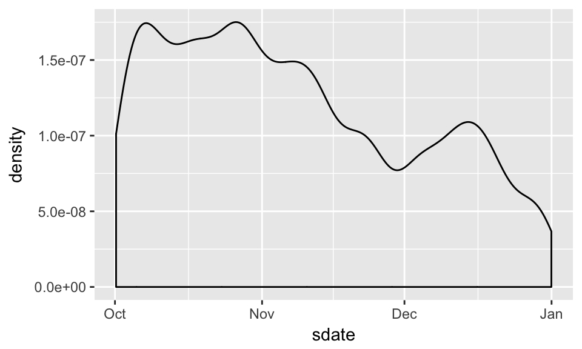

```r
Trips %>%
  ggplot(aes(x = sdate)) +
  geom_density()
```

2. A density plot of the events versus time of day. You can use `lubridate::hour()`, and `lubridate::minute()` to extract the hour of the day and minute within the hour from `sdate`, e.g.

```r
Trips <- Trips %>%
  mutate(time_of_day =
lubridate::hour(sdate) + lubridate::minute(sdate) / 60) %>%
  ... further processing ...
```

3. Facet (2) by day of the week. (Use `lubridate::wday()` to generate day of the week.)
4. Set the `fill` aesthetic for `geom_density()` to the `client` variable. You may also want to set the`alpha` for transparency and `color=NA` to suppress the outline of the density function.
- `client` describes whether the renter is a regular user (level `Registered`) or has not joined the bike-rental organization (`Causal`)

5.Same as (4) but using `geom_density()` with the argument `position = position_stack()`.

6. Rather than faceting on day of the week, consider creating a new faceting variable like this:

```r
mutate(wday = ifelse(lubridate::wday(sdate) %in% c(1,7), "weekend", "weekday"))
```

Your plot should look like:

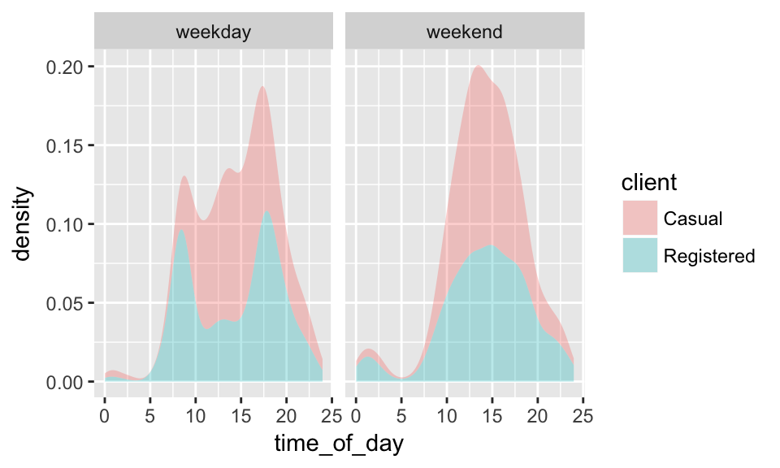

### Trip Distance

How does the start-to-end trip distance depend on time of day, day of the week, and client?

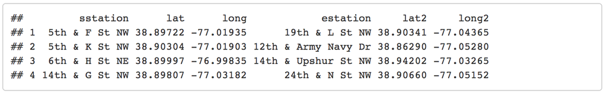

1. Make two copies of `Stations`, which we’ll call `Left` and `Right`. Left will have names `sstation`, `lat`, and `long`. `Right` will have names `estation`, `lat2`, and `long2`. The other variables, `nbBikes` and `nbEmptyDocks` should be dropped. Use the function `dpylr::rename()` to do the renaming of `name`,`lat`, and `long` (i.e. `dyplyr::rename(sstation=name)`).
2. Join `Left` and `Right` with a full outer join. This is a join in which every case in `Lef`t is matched to every case in `Right`. You can accomplish the full outer join with `Left%>% merge(Right,all=TRUE)`.

Of course, with the latitude and longitude of each station, you have enough information to calculate the distance between stations. This calculation is provided by the `haversine()` function, which you can load with

```r
source("http://tiny.cc/dcf/haversine.R")
```

Then…

3. Using the merged table, add a variable `dist` like this:

```r
mutate(dist = haversine(lat, long, lat2, long2))%>%
```

The end result, which we’ll call `Distances`, should look like this (this is a random sample so you won’t match it exactly):

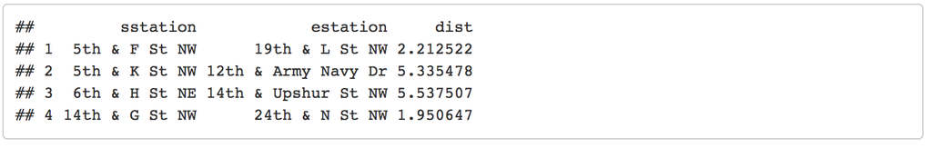

Join `Trips` to `Distances` to add a `dist` value for each trip.

## Distribtuions of Distances

1. Make a density plot of `dist` broken down by weekend vs weekday and by `client`.
2. Show the distribution of `dist` in a compact way with a violin plot or box and whiskers plot.For both `geom_violin()` and `geom_boxplot()`, you will want to map the `group` aesthetic to `hour`. For `geom_boxplot()`, you may prefer to set `outlier.size = 1`. You might also want to add a `stat_smooth()` layer. You should define `hours` as `hour = lubridate::hour(sdate)`.

For example, this is a possible plot:

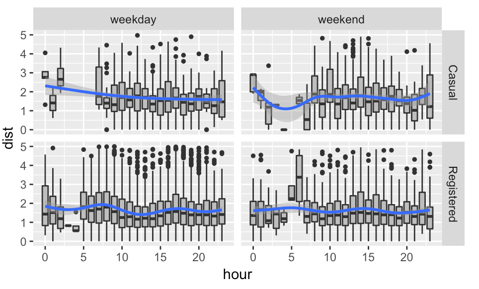